# Comparing econ-climate models

Emma Holmes

6/18/2020

# Climate-econ code

I have coded the climate-econ model, basing it on the economic model we have been using. This means it differs slightly from the model used by Bovari et al. in their 2018 papers (“Coping”" and “Debt and Damages”).

```r
# Packages
library("deSolve")
library("RColorBrewer")
colourful <- brewer.pal(n = 3, name = "Set1")

# Set-up
source('Code/June_2020/model_w_climate/pars.R')     # load parameters
source('Code/June_2020/model_w_climate/funcs.R')    # load functions
source('Code/June_2020/model_w_climate/sim.R')      # load simulation file
#==============================================================================
# ### Set initial conditions
lambda_init <-0.9
omega_init <-  0.9
debt_share_init <-0.2

IC <- c(
  K       =  lambda_init * Parms[['nu']],
  w       =  omega_init,
  p       =  1,
  debt    = debt_share_init * lambda_init,
  a       = 1,
  pop     = 1,
  g_sigma =  -0.0105,  # Growth rate of the emissions intensity of the economy
  n       =  0.03,     # Emissions reduction rate
  E_ind   =  35.85,    # Industrial CO2-e emissions, in Gt CO2-e
  CO2_AT  =  851,      # CO2-e concentration in the atmosphere layer, in Gt C
  CO2_UP  =  460,      # CO2-e concentration in the biosphere and upper ocean layer, in Gt C
  CO2_LO  =  1740,     # CO2-e concentration in the deep ocean layer, in Gt C
  E_land  =  2.6,      # Exogenous land use change CO2-e emissions, in Gt CO2-e
  p_BS    =  547.22,   # Backstop technology price level
  Temp    =  0.85,     # Temperature in the atmosphere, biosphere, and upper ocean layer, in degrees Celsius
  Temp_LO =  0.0068    # Temperature in the deep ocean layer, in degrees Celsius
)


#=================================================================================
# Set up simulation
Time <- c(
  start         =     2020,
  end           =     2120,
  step          =     0.05
)

Options <- list(
  invest = 'exp',  # exp / arctan / lin
  damage_scenario = 'None',
  p_carb_scheme = 'Low',
  subsidy = 0   # fraction of abatement costs subsidized by government
)
```

I run it without a carbon price or subsidy or climate damages, and it performs as teh previous code did:

### Good initial conditions

```r
IC[['n']] = 0
Parms[['carbon_slope']] = 0

Sim <- simulation(time       = Time,
                        init_state = IC,
                        parms      = Parms,
                        method     = 'rk4')
```

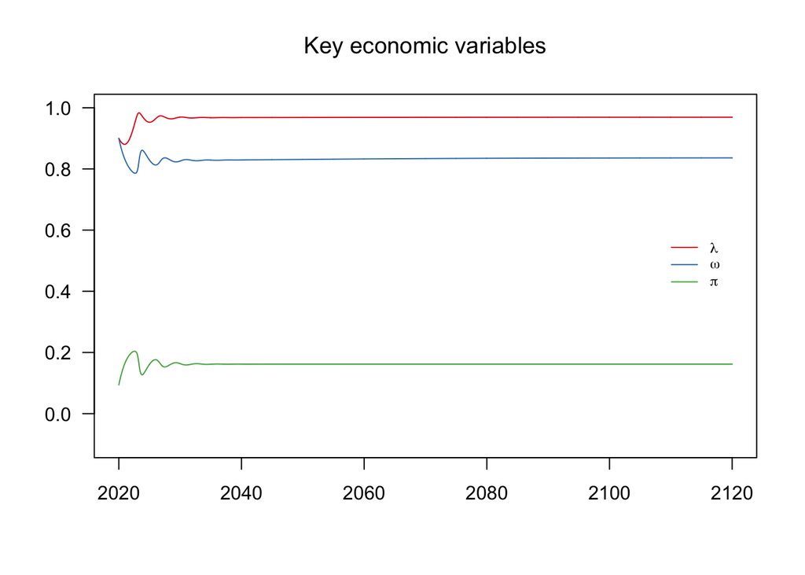

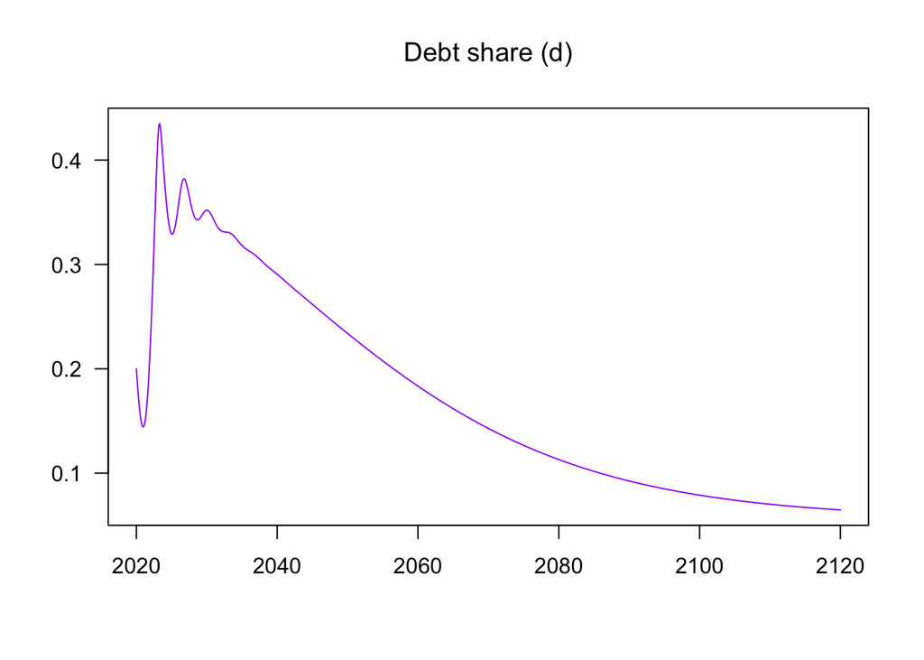

### Bad initial conditions

```r
lambda_init <-0.6
omega_init <- 0.7
debt_share_init <- 1.5
IC[['K']] = lambda_init * Parms[['nu']]
IC[['w']] = omega_init
IC[['debt']] = debt_share_init * lambda_init


Sim <- simulation(time       = Time,
                        init_state = IC,
                        parms      = Parms,
                        method     = 'rk4')
```

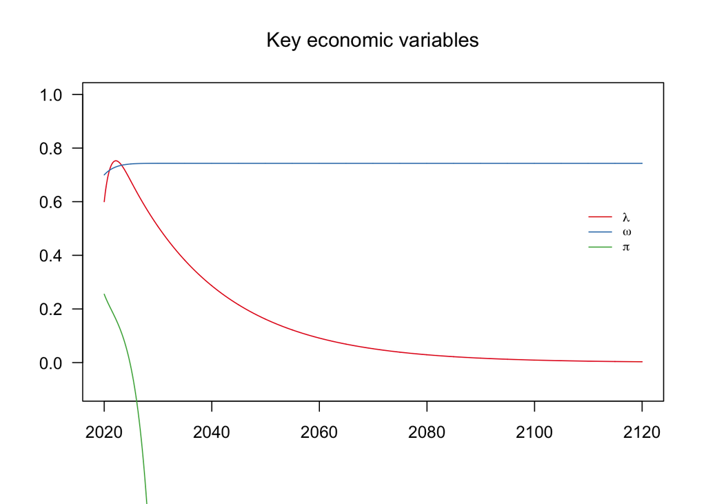

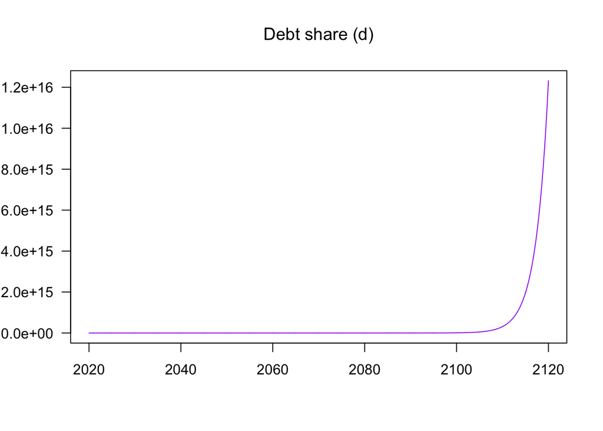

# Pricing differences

The AFD code has slightly different pricing dynamics. However, we can convert between what they used and what we are using.

AFD inflation:
$$i = \eta^*(\xi^* (\omega + \iota)-1)$$
$$= \eta^* \xi^* \omega + \eta^* \xi^* \iota - \eta^* \xi^*$$
$$= \eta(\xi\omega -1 )$$

where $\eta = \eta^* - \eta^* \xi^* \iota$ and $\xi = \frac{\xi^*}{1-\xi^* \iota}$. The AFD code also implies $\gamma=0$.

AFD parameters:

```r
eta.AFD     <- 0.3
markup.AFD  <- 1.2
omitted.AFD <- 0.3

eta <- eta.AFD - eta.AFD * markup.AFD * omitted.AFD
print(eta)
```

```
## [1] 0.192
```

```r
markup <- markup.AFD / (1 - markup.AFD * omitted.AFD)
print(markup)
```

```
## [1] 1.875
```

## Their code, their params

```r
source('Code/June_2020/original_AFD/0_main.R')
```

[output not shown]

[output cut: 17 more lines]

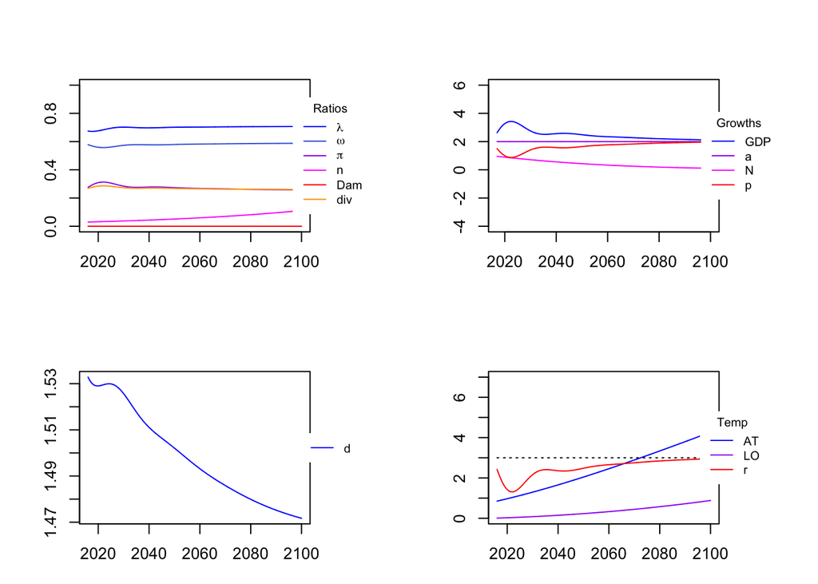

## Their code, our pricing params (with ‘omitted’ param)

```r
Pars_Sim[['eta']] = 3
Pars_Sim[['mu']] = 1.2

Simulation <- simulation(time             = Time_Sim,
                         init_sim         = Init_Sim,
                         control          = Control_Sim,
                         pars             = Pars_Sim,
                         active           = Active_Sim,
                         show_end_results = T)
```

```
##      year counter      Y      C      a   omega  lambda      pi        i
## 1681 2100      84 574.48 496.07 98.433 0.55826 0.85674 0.23226 0.089728
##           p       c      K      L     N     NG     D       d      w
## 1681 91.724 0.55826 1551.3 5.8369 6.813 11.288 38575 0.73205 5039.7
##            r      I Dam Dam_K Dam_Y     E E_land  E_ind  sigma CO2_AT
## 1681 0.13459 78.411   0     0     0 135.9 0.4093 135.49 0.2655   2155
##      CO2_UP CO2_LO  F_ind F_exo Forcing  Temp Temp_LO          A   p_BS
## 1681 1006.8 1774.3 6.8979     1  7.8979 4.432  0.8989 0.00012262 358.02
##       p_Car g_p_Car       n   Div sigma.1  T_G_c S_G_c     Y0     r.1
## 1681 10.744    0.02 0.11176 13085  0.2655 1.6897     0 574.55 0.13459
##         Pi Net.transfer      CR  DGdeficit    DGdebt
## 1681 12239      -1.6897 0.19711 -0.0029413 -0.025699
## [1] "-----------"
##    user  system elapsed
##   2.634   0.028   2.828
```

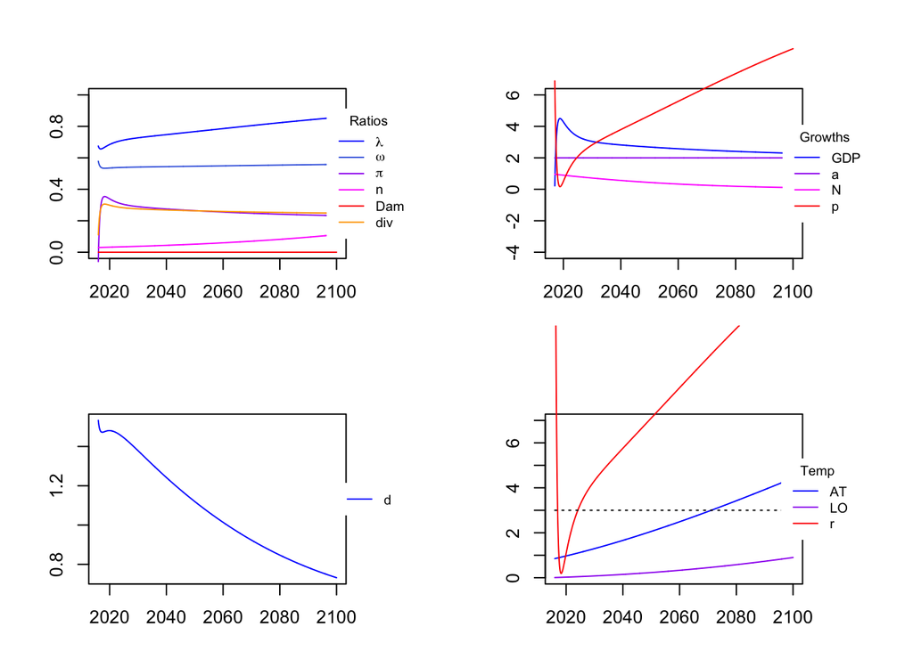

## Their code, our pricing params (no ‘omitted’ param)

```r
Pars_Sim[['omitted']] = 0

Simulation <- simulation(time             = Time_Sim,
                         init_sim         = Init_Sim,
                         control          = Control_Sim,
                         pars             = Pars_Sim,
                         active           = Active_Sim,
                         show_end_results = T)
```

```
##      year counter   Y   C      a omega lambda  pi   i   p   c   K   L
## 1681 2100      84 NaN NaN 98.433   NaN    NaN NaN NaN NaN NaN NaN NaN
##          N     NG   D   d   w   r   I Dam Dam_K Dam_Y   E E_land E_ind
## 1681 6.813 11.288 NaN NaN NaN NaN NaN NaN   NaN   NaN NaN 0.4093   NaN
##       sigma CO2_AT CO2_UP CO2_LO F_ind F_exo Forcing Temp Temp_LO
## 1681 0.2655    NaN    NaN    NaN   NaN     1     NaN  NaN     NaN
##               A   p_BS  p_Car g_p_Car       n Div sigma.1 T_G_c S_G_c  Y0
## 1681 0.00012262 358.02 10.744    0.02 0.11176 NaN  0.2655   NaN   NaN NaN
##      r.1  Pi Net.transfer  CR DGdeficit DGdebt
## 1681 NaN NaN          NaN NaN       NaN    NaN
## [1] "-----------"
##    user  system elapsed
##   2.569   0.017   2.653
```

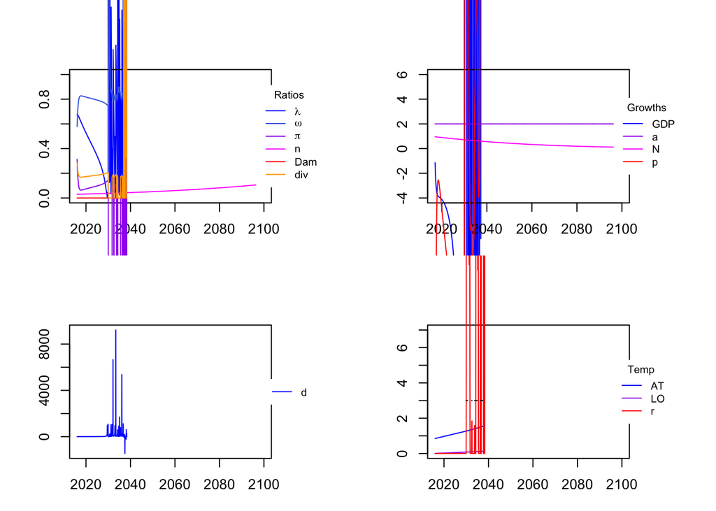

## Our code, their params

```r
# Set-up
source('Code/June_2020/model_w_climate/pars.R')     # load parameters
source('Code/June_2020/model_w_climate/funcs.R')    # load functions
source('Code/June_2020/model_w_climate/sim.R')      # load simulation file
#==============================================================================
# ### Set initial conditions
lambda_init <-0.9
omega_init <-  0.9
debt_share_init <-0.2

IC <- c(
  K       =  lambda_init * Parms[['nu']],
  w       =  omega_init,
  p       =  1,
  debt    = debt_share_init * lambda_init,
  a       = 1,
  pop     = 1,
  g_sigma =  -0.0105,  # Growth rate of the emissions intensity of the economy
  n       =  0.03,     # Emissions reduction rate
  E_ind   =  35.85,    # Industrial CO2-e emissions, in Gt CO2-e
  CO2_AT  =  851,      # CO2-e concentration in the atmosphere layer, in Gt C
  CO2_UP  =  460,      # CO2-e concentration in the biosphere and upper ocean layer, in Gt C
  CO2_LO  =  1740,     # CO2-e concentration in the deep ocean layer, in Gt C
  E_land  =  2.6,      # Exogenous land use change CO2-e emissions, in Gt CO2-e
  p_BS    =  547.22,   # Backstop technology price level
  Temp    =  0.85,     # Temperature in the atmosphere, biosphere, and upper ocean layer, in degrees Celsius
  Temp_LO =  0.0068    # Temperature in the deep ocean layer, in degrees Celsius
)


#=================================================================================
# Set up simulation
Time <- c(
  start         =     2020,
  end           =     2120,
  step          =     0.05
)

Options <- list(
  invest = 'exp',  # exp / arctan / lin
  damage_scenario = 'None',
  p_carb_scheme = 'Low',
  subsidy = 0   # fraction of abatement costs subsidized by government
)

IC[['n']] = 0
Parms[['carbon_slope']] = 0
Parms[['eta_p']] = 0.192
Parms[['markup']] = 1.875
Parms[['gamma']] = 0

Sim <- simulation(time       = Time,
                        init_state = IC,
                        parms      = Parms,
                        method     = 'rk4')
```

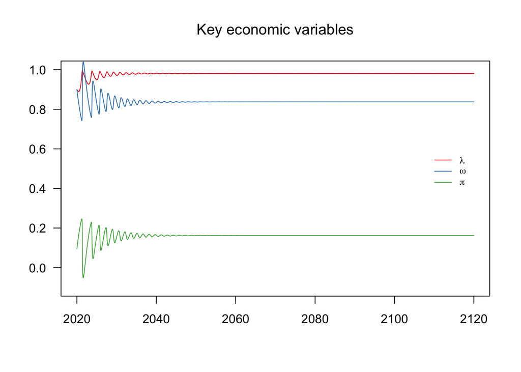

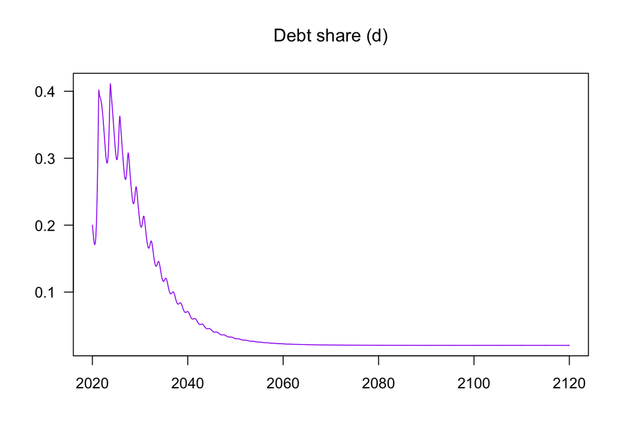

## Basin search

What happens if the AFD pricing parameters are used with the basin search code? It was previously observed that a higher markup rate $\xi$ increased the basin of attraction to the ‘good’ equilibrium.

I ran the basin search code with $\eta = 0.192$, $\xi=1.875$, and $\gamma=0$.

```r
source('Code/May_2020/compare_models/basin_search.R')
result <- compute.basin.3d(n_pts=10,  eta=0.192, markup = 1.875, gamma=0, type="sobol")
```

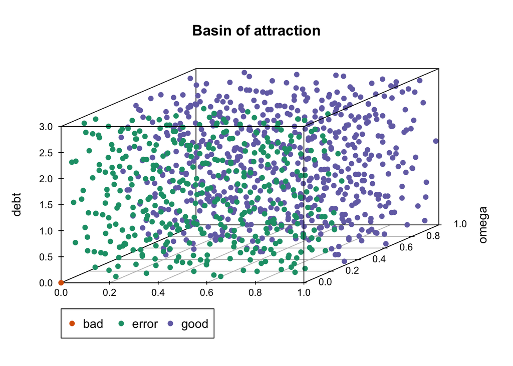

# Thoughts

- my climate-econ code always crashes with significant carbon pricing. Should I adjust pricing parameters so this doesn’t happen (if possible)?
- which pricing parameters to use?
- how to implement carbon pricing? Right now it is linear, but it should probably be capped.